# 3: Structural Topic Modeling

Jennifer Frehn

4/25/2018

### Description of Script

This script loads, preprocesses and conducts descriptive structural topic modeling text analysis on the datasets all_f.csv and all_m.csv. It then produces visualizations of these results.

### Set up Environment

```r
setwd("/Users/JenniferF/Box Sync/Cal 2018 Spring Courses/jf_PS239T/Final Project Planning/R Files") # YOUR DIRECTORY HERE
rm(list=ls())

# Load Libraries
library(stm) # Structural Topic Modeling package
library(dplyr)
```

# STM for Female Senators

### 1. Read in CSVs (Females)

Reading in csv, with each row being a document, and columns for text and metadata.

```r
all_f.df <-read.csv("all_f.csv", header=TRUE) # Read in CSV file
```

### 2. STM Pre-processing (Females)

Conducting pre-processing on the dataset using stm’s built-in package.

```r
# Pre-processing - Female
temp<-textProcessor(documents=all_f.df$newplaintext, metadata=all_f.df)
```

```
## Building corpus...
## Converting to Lower Case...
## Removing punctuation...
## Removing stopwords...
## Removing numbers...
## Stemming...
## Creating Output...
```

```r
meta<-temp$meta
vocab<-temp$vocab
docs<-temp$documents
out <- prepDocuments(docs, vocab, meta, lower.thresh=10) # removing words that appear in fewer than 10 tweets
```

```
## Removing 24753 of 28613 terms (45038 of 576312 tokens) due to frequency
## Removing 207 Documents with No Words
## Your corpus now has 55561 documents, 3860 terms and 531274 tokens.
```

```r
docs<-out$documents
vocab<-out$vocab
meta <-out$meta
```

### 3. Estimate Topic Model (Females)

We’re now going to estimate a topic model with 15 topics by regressing topical prevalence on the recipient of the tweet (“reply_to_screen_name”).

```r
# Topic model without "max.em.its" argument, so that the argument can run to convergence
#model <- stm(docs,vocab, 15, prevalence=~reply_to_screen_name, data=meta, seed = 15)

# Topic model with "max.em.its" argument
#model <- stm(docs,vocab, 15, prevalence=~reply_to_screen_name, data=meta, seed = 15, max.em.its = 50)

# Saving the model
#save(model, file = "stm15_f.RData")

# Loading the already-estimated model
load("stm15_f.RData")
```

### 4. Explore the Model (Females)

##### 4.1 Topic Quality (Females)

We use the `topicQuality` command to examine the quality of the topics. The x axis shows how coherent a topic is, and the y axis shows exclusivity. We then save this image as a PDF.

```
##  [1] -154.3954 -130.3937 -173.9496 -140.9769 -144.3350 -169.5480 -147.2617
##  [8] -146.8396 -163.4292 -148.8349 -114.3083 -143.4578 -113.6385 -149.0376
## [15] -141.1742
##  [1] 9.753969 9.840964 9.744621 9.861162 9.594927 9.848091 9.755823
##  [8] 9.763627 9.610722 9.828638 9.926469 9.702393 9.919295 9.754418
## [15] 9.911990
```

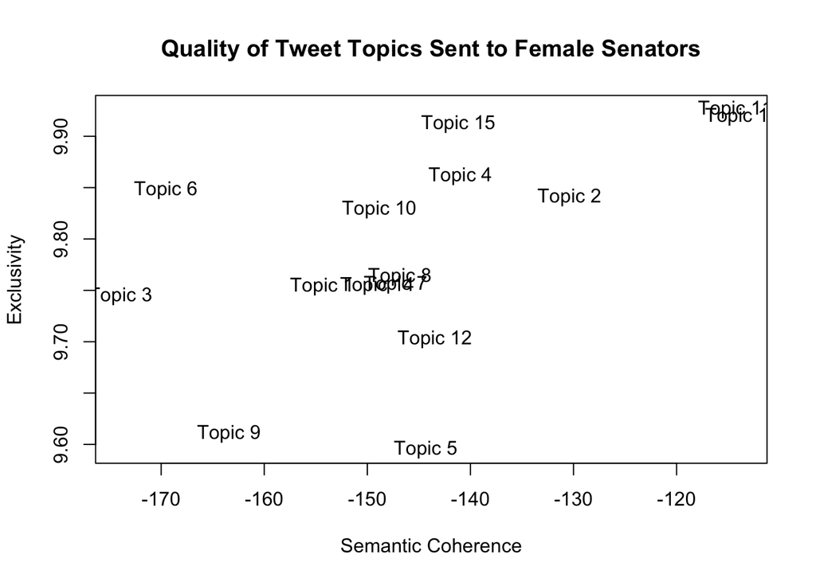

```r
# Topic Quality plot
topicQuality(model=model, documents=docs, main="Quality of Tweet Topics Sent to Female Senators")
```

```r
# Saving Topic Quality plot
pdf('topic_quality_f.pdf')
topicQuality(model=model, documents=docs, main="Quality of Tweet Topics Sent to Female Senators")
```

```
##  [1] -154.3954 -130.3937 -173.9496 -140.9769 -144.3350 -169.5480 -147.2617
##  [8] -146.8396 -163.4292 -148.8349 -114.3083 -143.4578 -113.6385 -149.0376
## [15] -141.1742
##  [1] 9.753969 9.840964 9.744621 9.861162 9.594927 9.848091 9.755823
##  [8] 9.763627 9.610722 9.828638 9.926469 9.702393 9.919295 9.754418
## [15] 9.911990
```

```r
dev.off()
```

##### 4.2 Top Words & Finding Thoughts (Females)

Here we will use the `labelTopics` command (which gives the top words for each topic) and the `findThoughts` command (which pulls example tweets that relate to each topic) in order to help us determine labels for each of the 15 topics. First, we will read the top words and determine labels for those topics, then for those topics that still seem unclear, we will examine the actual tweets from those topics to help us determine a label.

```r
# Top Words - Female
labelTopics(model)
```

```
## Topic 1 Top Words:
##       Highest Prob: just, like, your, one, look, realli, see
##       FREX: tweet, anoth, stupid, idiot, race, divid, wow
##       Lift: recycl, baiter, meaningless, video, tweet, bait, delet
##       Score: just, your, recycl, tweet, stupid, like, anoth
## Topic 2 Top Words:
##       Highest Prob: support, babi, kill, abort, women, plan, murder
##       FREX: babi, murder, abort, opportun, unborn, parenthood, reproduct
##       Lift: killer, reproduc, babi, dismemb, pro-lif, infanticid, womb
##       Score: killer, babi, abort, murder, kill, women, parenthood
## Topic 3 Top Words:
##       Highest Prob: pleas, run, can, yes, need, ask, shut
##       FREX: pleas, run, leadership, dna, pompeo, yes, progress
##       Lift: pound, driftnet, gaza, corybook, demonstr, drift, elizabethforma
##       Score: pleas, pound, run, yes, shut, speak, pocahonta
## Topic 4 Top Words:
##       Highest Prob: obama, didnt, never, anyth, dem, promis, democrat
##       FREX: promis, got, daca, didnt, offer, made, gave
##       Lift: mous, revok, temporari, promis, squat, blew, pad
##       Score: promis, mous, obama, didnt, daca, got, made
## Topic 5 Top Words:
##       Highest Prob: gun, nra, use, control, respons, right, attack
##       FREX: nra, weapon, respons, gun, arm, amend, lack
##       Lift: lethal, ar-, rifl, ownership, semi, arrow, chronic
##       Score: nra, gun, weapon, lethal, respons, control, attack
## Topic 6 Top Words:
##       Highest Prob: senat, thank, cfpb, love, great, fight, mickmulvaneyomb
##       FREX: mickmulvaneyomb, cfpb, franken, senat, thank, fight, senduckworth
##       Lift: easter, mick, mickmulvaneyomb, franken, duckworth, senjoniernst, alfranken
##       Score: senat, easter, cfpb, thank, mickmulvaneyomb, warren, fight
## Topic 7 Top Words:
##       Highest Prob: realdonaldtrump, congress, trump, doesnt, someth, done, constitut
##       FREX: realdonaldtrump, pattymurray, approv, doesnt, indian, act, clear
##       Lift: cnnbrk, yawn, usrepk, tpp, repmcgovern, pattymurray, repjoekennedi
##       Score: realdonaldtrump, yawn, congress, doesnt, pattymurray, war, constitut
## Topic 8 Top Words:
##       Highest Prob: elect, hillari, investig, russia, russian, clinton, democrat
##       FREX: hillari, clinton, russia, russian, dnc, interfer, collus
##       Lift: chariti, cra, harvey, dossier, collud, interf, server
##       Score: elect, russian, hillari, russia, clinton, investig, collus
```

[output cut: 20 more lines]

```
## Topic 13 Top Words:
##       Highest Prob: illeg, american, law, countri, citizen, care, immigr
##       FREX: citizen, crimin, legal, immigr, afraid, theyr, deport
##       Lift: lover, obey, arbitrarili, breaker, steinl, sneak, kate
##       Score: illeg, immigr, citizen, legal, law, american, alien
## Topic 14 Top Words:
##       Highest Prob: will, trump, protect, mueller, epa, need, now
##       FREX: fire, mcconnel, impeach, mueller, protect, special, pass
##       Lift: rod, mitch, senmajldr, preetbharara, fire, mcconnel, ryan
##       Score: mueller, fire, protect, epa, rod, hes, trump
## Topic 15 Top Words:
##       Highest Prob: will, think, vote, good, make, way, know
##       FREX: sure, good, truth, think, better, way, thing
##       Lift: pallet, kitchen, luck, quiet, theyll, sent, greatest
##       Score: pallet, vote, good, think, will, sure, truth
```

```r
# Example Docs - Female
findThoughts(model,texts=meta$newplaintext,n=3,topics=c(4)) # Pulls 3 tweets from topic 4.
```

```
##
##  Topic 4:
##       Americans didn't promise anything, we didn't vote on it. Obama created DACA by executive order
##      I didn't promise them anything! And Obama said it was temporary. So who made that promise?
##      Demi had a chance - FAILED Not DJT's fault - DEMS Screwed Up. THE PRESIDENT has no obligation to play juvenile Dem games. Gave them a chance, DEMS FAILED!!!
```

```r
# Labels for female topics
labels = c("Shooting Response", "Abortion", "Misc", "DACA", "Guns", "Praise", "Trump", "Hillary & Russia", "Jobs", "Kamala's Ellen Appearance", "Taxes", "Social Issues", "Immigration", "EPA & Mueller",  "Voting")
```

##### 4.3 Image of Topics (Females)

Below we will generate images of the keywords used in each topic. We will save images of the keywords as PDFs.

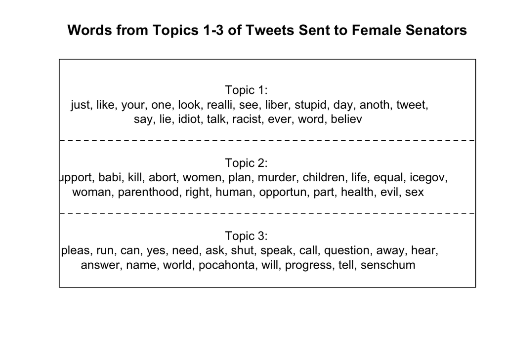

```r
# Generate image of topics
plot(model, type="labels", topics=c(1:3), main = "Words from Topics 1-3 of Tweets Sent to Female Senators")
```

```r
# Save image of topics - Female
pdf('F Topics 1_7.pdf')
plot(model, type="labels", topics=c(1:7), main = "Words from Topics 1-7 of Tweets Sent to Female Senators")
dev.off()
```

```r
pdf('F Topics 8_15.pdf')
plot(model, type="labels", topics=c(8:15), main = "Words from Topics 8-15 of Tweets Sent to Female Senators")
dev.off()
```

##### 4.4 Word Cloud (Females)

Here we will examine the word cloud for one of the topics that was similar for both groups: Taxes. We then save this image as a PDF.

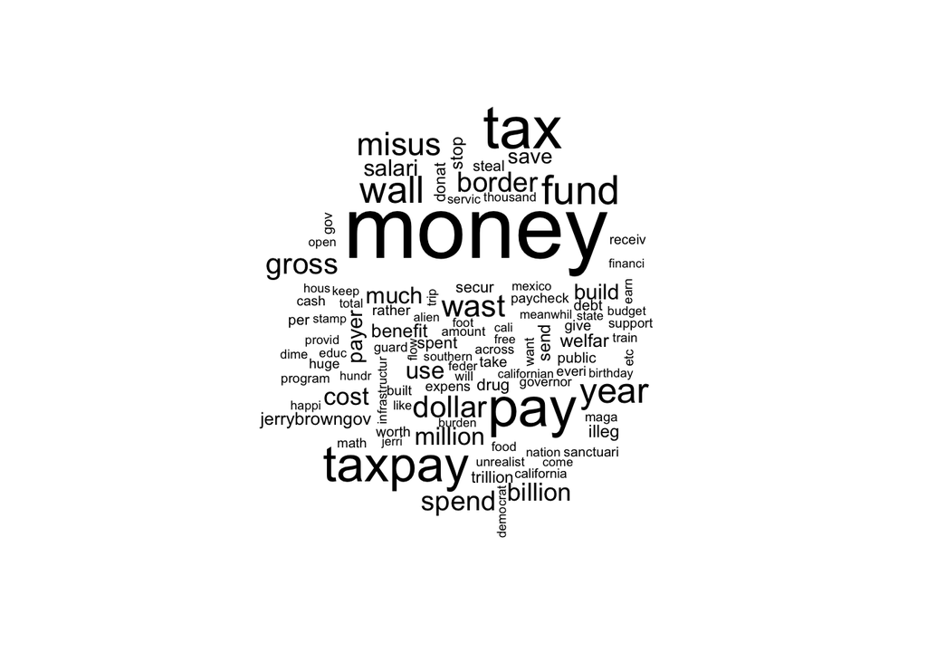

```r
# Word Cloud
cloud(model, topic=11)
```

```r
# Saving word cloud - Females
pdf('cloud_f_taxes.pdf')
cloud(model, topic=11)
dev.off()
```

### 5. Analyze Topics (Females)

##### 5.1 Topic Prevalence (Females)

We’re now going to see how the topics compare in terms of their prevalence/proportion. We then save this image as a PDF.

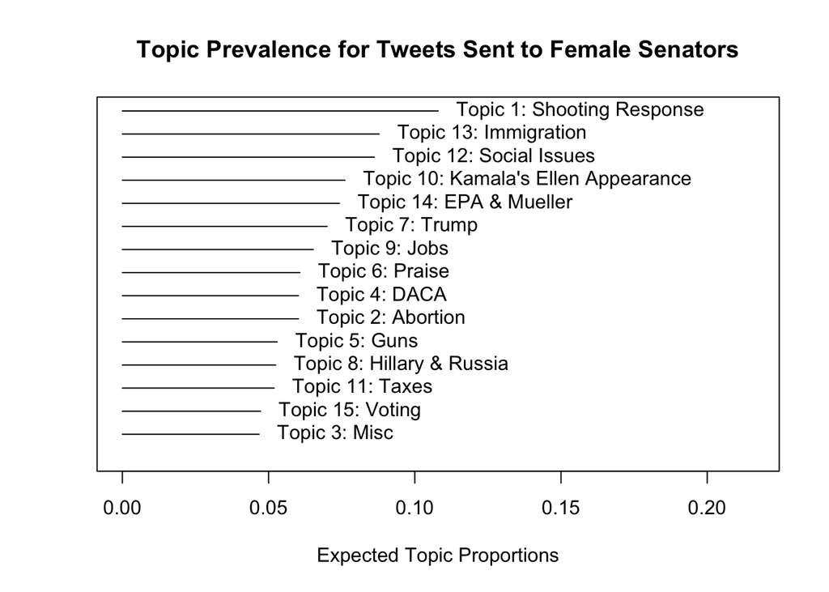

```r
# Corpus Summary using custom labels created earlier
plot.STM(model,type="summary",custom.labels=labels,main="Topic Prevalence for Tweets Sent to Female Senators")
```

```r
# Saving Corpus Summary - Female
pdf('TopicProportions_F.pdf')
plot.STM(model,type="summary",custom.labels=labels,main="Topic Prevalence for Tweets Sent to Female Senators")
dev.off()
```

##### 5.2 Topic Correlation (Females)

Below we take a look at how the `topicCorr` command predicts that the topics are correlated. We then save this prediction image as a PDF.

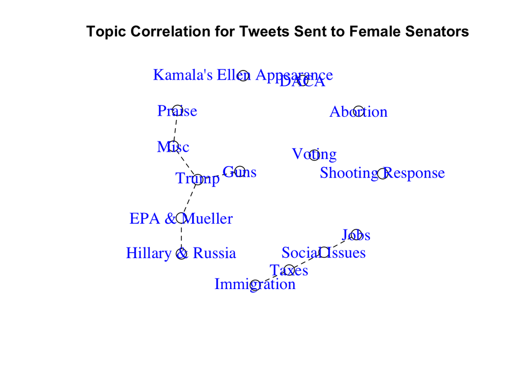

```r
# Topic Correlation
mod.out.corr<-topicCorr(model)
plot.topicCorr(mod.out.corr, vlabels=labels, vertex.color="white", vertex.label.cex= 1.3, vertex.label.color="blue", vertex.size = 10, main="Topic Correlation for Tweets Sent to Female Senators")
```

```r
# Saving Topic Correlation - Female
pdf('TopicCorrelation_F.pdf')
plot.topicCorr(mod.out.corr, vlabels=labels, vertex.color="white", vertex.label.cex= 1.5, vertex.label.color="blue", vertex.size = 14, main="Topic Correlation for Tweets Sent to Female Senators")
dev.off()
```

##### 5.3 Estimating Covariate Effects (Females)

The below plot shows the effect of the covariate “senator” on the topic of interest. In this case, topic 2. The outcome is the proportion of the reply tweets sent to each senator that is about topic 2.

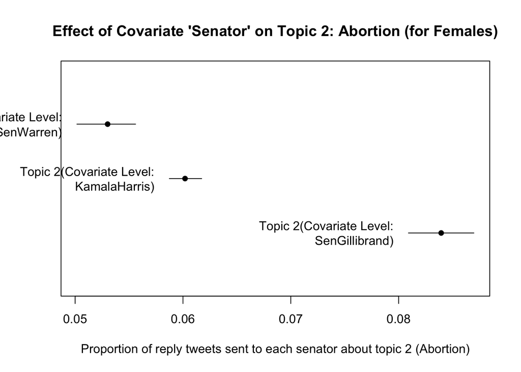

```r
# Estimate Covariate Effects
prep <- estimateEffect(1:15 ~ reply_to_screen_name,model,meta=meta,uncertainty="Global",documents=docs)

# Topics over Senator - FEMALE
plot.estimateEffect(prep,"reply_to_screen_name",method="pointestimate",topics=2,printlegend=TRUE,main="Effect of Covariate 'Senator' on Topic 2: Abortion (for Females)",ci.level=.95,nsims=100, xlab="Proportion of reply tweets sent to each senator about topic 2 (Abortion)")
```

```r
# Saving Covariate Effects
pdf('TopicCovariate_F.pdf')
plot.estimateEffect(prep,"reply_to_screen_name",method="pointestimate",topics=2,printlegend=TRUE,main="Effect of Covariate 'Senator' on Topic 2: Abortion (for Females)",ci.level=.95,nsims=100, xlab="Proportion of reply tweets sent to each senator about topic 2 (Abortion)")
dev.off()
```

# STM for Male Senators

### 1. Read in CSVs (Males)

Reading in csv, with each row being a document, and columns for text and metadata.

```r
rm(list=ls())
all_m.df <-read.csv("all_m.csv", header=TRUE) # Read in CSV file
```

### 2. STM Pre-processing (Males)

Conducting pre-processing on the dataset using stm’s built-in package.

```r
# Pre-processing - Male
temp<-textProcessor(documents=all_m.df$newplaintext, metadata=all_m.df)
```

```
## Building corpus...
## Converting to Lower Case...
## Removing punctuation...
## Removing stopwords...
## Removing numbers...
## Stemming...
## Creating Output...
```

```r
meta<-temp$meta
vocab<-temp$vocab
docs<-temp$documents
out <- prepDocuments(docs, vocab, meta, lower.thresh=10) # removing words that appear in fewer than 10 tweets
```

```
## Removing 17729 of 20524 terms (34302 of 316195 tokens) due to frequency
## Removing 132 Documents with No Words
## Your corpus now has 29479 documents, 2795 terms and 281893 tokens.
```

```r
docs<-out$documents
vocab<-out$vocab
meta <-out$meta
```

### 3. Estimate Topic Model (Males)

We’re now going to estimate a topic model with 15 topics by regressing topical prevalence on the recipient of the tweet (“reply_to_screen_name”).

```r
# Topic model without "max.em.its" argument, so that the argument can run to convergence
#model <- stm(docs,vocab, 15, prevalence=~reply_to_screen_name, data=meta, seed = 15)

# Topic model with "max.em.its" argument
#model <- stm(docs,vocab, 15, prevalence=~reply_to_screen_name, data=meta, seed = 15, max.em.its = 50)

# Saving the model
#save(model, file = "stm15_m.RData")

# Loading the already-estimated model
load("stm15_m.RData")
```

### 4. Explore the Model (Males)

##### 4.1 Topic Quality (Males)

We use the `topicQuality` command to examine the quality of the topics. The x axis shows how coherent a topic is, and the y axis shows exclusivity.

```
##  [1] -133.5451 -147.7841 -122.4439 -180.5638 -209.3009 -122.0747 -145.6485
##  [8] -140.0082 -140.1648 -186.1084 -145.3652 -117.4937 -166.0992 -132.3709
## [15] -160.0201
##  [1] 9.679706 9.682709 9.750004 9.885200 9.759245 9.793078 9.712260
##  [8] 9.769000 9.790202 9.548120 9.695875 9.914758 9.747832 9.789762
## [15] 9.890256
```

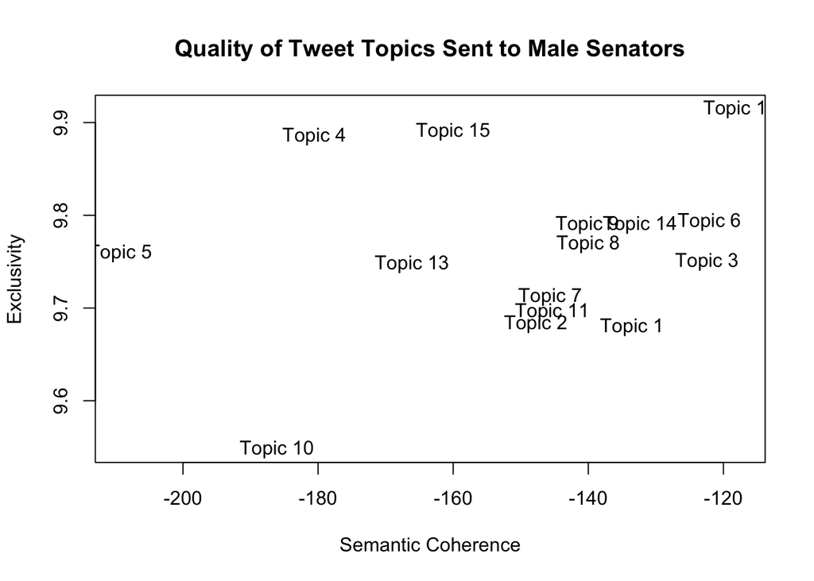

```r
# Topic Quality plot
topicQuality(model=model, documents=docs, main="Quality of Tweet Topics Sent to Male Senators")
```

```r
# Saving Topic Quality plot
pdf('topic_quality_m.pdf')
topicQuality(model=model, documents=docs, main="Quality of Tweet Topics Sent to Male Senators")
```

```
##  [1] -133.5451 -147.7841 -122.4439 -180.5638 -209.3009 -122.0747 -145.6485
##  [8] -140.0082 -140.1648 -186.1084 -145.3652 -117.4937 -166.0992 -132.3709
## [15] -160.0201
##  [1] 9.679706 9.682709 9.750004 9.885200 9.759245 9.793078 9.712260
##  [8] 9.769000 9.790202 9.548120 9.695875 9.914758 9.747832 9.789762
## [15] 9.890256
```

```r
dev.off()
```

##### 4.2 Top Words & Finding Thoughts (Males)

Here we will use the `labelTopics` command (which gives the top words for each topic) and the `findThoughts` command (which pulls example tweets that relate to each topic) in order to help us determine labels for each of the 15 topics. First, we will read the top words and determine labels for those topics, then for those topics that still seem unclear, we will examine the actual tweets from those topics to help us determine a label.

```r
# Top Words - Male
labelTopics(model)
```

```
## Topic 1 Top Words:
##       Highest Prob: tax, money, work, year, pay, job, cut
##       FREX: tax, spend, dollar, money, rais, worker, bonus
##       Lift: obozo, trillion, deficit, bonus, debt, stockhold, ira
##       Score: tax, money, obozo, cut, pay, year, bonus
## Topic 2 Top Words:
##       Highest Prob: get, can, pleas, stop, need, someth, help
##       FREX: nancypelosi, sengillibrand, fight, senfeinstein, pleas, kamalaharri, senwarren
##       Lift: joebiden, senatorcardin, teampelosi, guard, timkain, maxinewat, markwarn
##       Score: get, pleas, teampelosi, can, nancypelosi, war, sengillibrand
## Topic 3 Top Words:
##       Highest Prob: lie, investig, fbi, hillari, russia, russian, realdonaldtrump
##       FREX: clinton, collus, doj, russian, email, branch, russia
##       Lift: hush, server, eric, loretta, dossier, chatter, delet
##       Score: investig, hush, lie, hillari, collus, clinton, russian
## Topic 4 Top Words:
##       Highest Prob: realdonaldtrump, chuck, schumer, thejusticedept, fuck, idiot, shut
##       FREX: shut, schumer, cri, fuck, idiot, chuck, yeah
##       Lift: lier, crocodil, sunday, snowwhiteiam, shut, cri, crybabi
##       Score: realdonaldtrump, chuck, schumer, thejusticedept, lier, fuck, shut
## Topic 5 Top Words:
##       Highest Prob: polit, love, much, better, speak, black, true
##       FREX: race, true, matter, facebook, lol, term, stfu
##       Lift: baiter, regret, asid, race, lol, luther, zuckerberg
##       Score: baiter, race, black, love, true, facebook, polit
## Topic 6 Top Words:
##       Highest Prob: trump, mueller, fire, know, potus, will, hes
##       FREX: fire, impeach, fdni, trump, rosenstein, hope, well
##       Lift: sprinkler, fdni, fire, rod, session, impeach, sentiment
##       Score: fire, mueller, trump, sprinkler, rosenstein, potus, witch
## Topic 7 Top Words:
##       Highest Prob: peopl, one, american, care, that, say, dont
##       FREX: that, total, anyon, news, surpris, care, fraud
##       Lift: aslavitt, devil, comedi, that, welcom, tick, cuz
##       Score: aslavitt, that, peopl, one, care, american, anyon
## Topic 8 Top Words:
##       Highest Prob: senatedem, law, realdonaldtrump, senategop, illeg, constitut, american
##       FREX: senategop, senatedem, senatortomudal, senschum, crap, legal, illeg
##       Lift: load, cross, senatortomudal, client, alien, abid, seizur
##       Score: senatedem, load, senategop, illeg, law, senschum, constitut
```

[output cut: 20 more lines]

```
## Topic 13 Top Words:
##       Highest Prob: state, man, hate, white, racist, person, hypocrit
##       FREX: racist, religi, christian, belief, bigot, hate, test
##       Lift: brigitt, rabid, gabriel, test, actbrigitt, disqualifi, religi
##       Score: rabid, racist, christian, religi, state, hate, belief
## Topic 14 Top Words:
##       Highest Prob: realdonaldtrump, senatemajldr, need, senat, protect, will, republican
##       FREX: senatemajldr, mcconnel, mitch, gop, protect, protectmuel, traitor
##       Lift: presssec, mitch, senmajldr, protectrosenstein, mcconnel, protectmuel, turtl
##       Score: senatemajldr, realdonaldtrump, mcconnel, protect, presssec, gop, bill
## Topic 15 Top Words:
##       Highest Prob: america, thing, good, make, see, like, day
##       FREX: gingrich, alway, thing, america, name, sad, politician
##       Lift: senil, adulter, slime, diseas, deplor, despic, gingrich
##       Score: senil, gingrich, america, thing, alway, good, day
```

```r
# Example Docs - Male
findThoughts(model,texts=meta$newplaintext,n=3,topics=c(3)) # Pulls 3 tweets from topic 3.
```

```
##
##  Topic 3:
##       @realDonaldTrump Hillary Pay to Play Clinton Foundation Sold 20% of USA Uranium to Russia Private server was hacked by 5-6 Governments Lied about not having classified info Destroyed emails Destroyed devices Hillary paid for Russian Dossier which was used for FISA Warrant
##      @realDonaldTrump MULLER should have never been appointed, & U know this. There has to be a crime present to appoint a special council. There was no crime present. This is in the document determining what provokes a special council. PLUS, collusion is NOT A CRIME.
##      @realDonaldTrump Who didn't get raided by the FBI: -Eric Holder -Hillary Clinton -Loretta Lynch -John Podesta -Donna Brazile -Debbie Wasserman Schultz -Robby Moot -David Brock -Susan Rice -Huma Abedin -Anthony Weiner -Harvey Weinstein -Burns Strider But Michael Cohen does?
```

```r
# Labels for male topics
labels = c("Taxes", "Military", "Hillary & Russia", "Anti-Chuck", "Race", "Mueller", "Misc1", "Misc2", "Anti-Bernie", "Israel", "Gateway Bridge", "Pompeo", "Religion", "McConnell", "Gingrich")
```

##### 4.3 Image of Topics (Males)

Below we will generate images of the keywords used in each topic. We will save images of the keywords as PDFs.

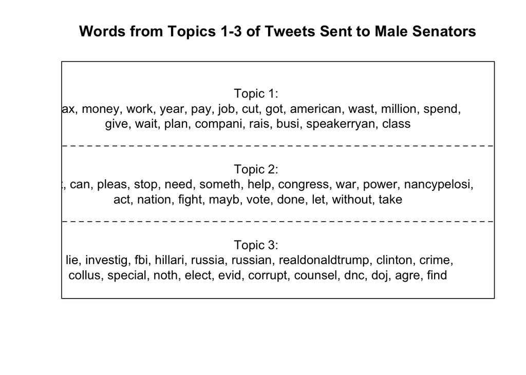

```r
# Generate image of topics
plot(model, type="labels", topics=c(1:3), main = "Words from Topics 1-3 of Tweets Sent to Male Senators") # Topics 1-3
```

```r
# Save image of topics - Male
pdf('M Topics 1_7.pdf')
plot(model, type="labels", topics=c(1:7), main = "Words from Topics 1-7 of Tweets Sent to Male Senators") # Topics 1-7
dev.off()
```

```r
pdf('M Topics 8_15.pdf')
plot(model, type="labels", topics=c(8:15), main = "Words from Topics 8-15 of Tweets Sent to Male Senators") # Topics 8-15
dev.off()
```

##### 4.4 Word Cloud (Males)

Here we will examine the word cloud for one of the topics that was similar for both groups: Taxes.

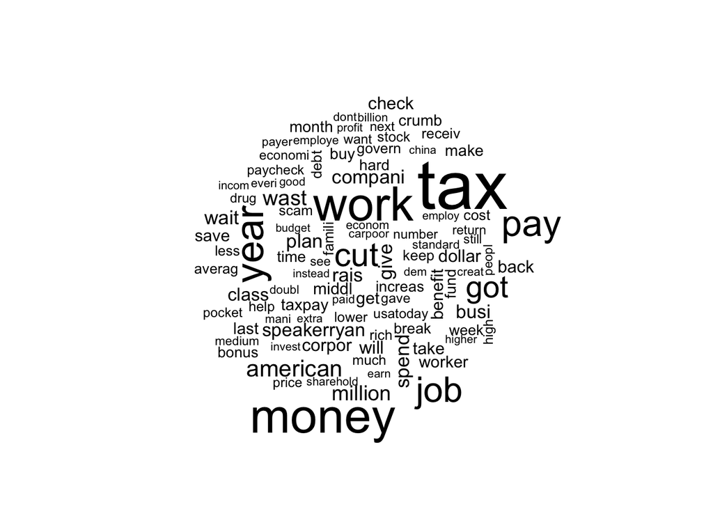

```r
# Word Cloud
cloud(model, topic=1)
```

```r
# Saving word cloud - Males
pdf('cloud_m_taxes.pdf')
cloud(model, topic=1)
dev.off()
```

### 5. Analyze Topics (Males)

##### 5.1 Topic Prevalence (Males)

We’re now going to see how the topics compare in terms of their prevalence/proportion.

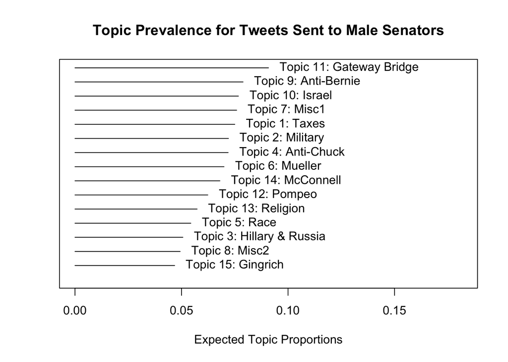

```r
# Corpus Summary using custom labels created earlier
plot.STM(model,type="summary",custom.labels=labels,main="Topic Prevalence for Tweets Sent to Male Senators")
```

```r
# Saving Corpus Summary - Male
pdf('TopicProportions_M.pdf')
plot.STM(model,type="summary",custom.labels=labels,main="Topic Prevalence for Tweets Sent to Male Senators")
dev.off()
```

##### 5.2 Topic Correlation (Males)

Below we take a look at how the `topicCorr` command predicts that the topics are correlated. We then save this prediction image as a PDF.

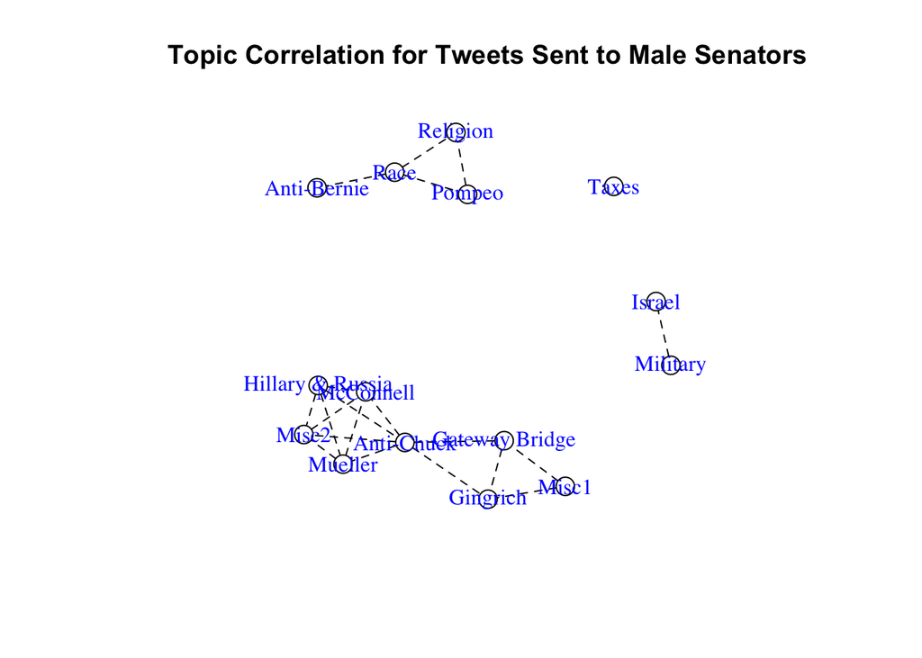

```r
# Topic Correlation
mod.out.corr<-topicCorr(model)
plot.topicCorr(mod.out.corr, vlabels=labels, vertex.color="white", vertex.label.cex= 1, vertex.label.color="blue", vertex.size = 10, main="Topic Correlation for Tweets Sent to Male Senators")
```

```r
# Saving Topic Correlation - Male
pdf('TopicCorrelation_M.pdf')
plot.topicCorr(mod.out.corr, vlabels=labels, vertex.color="white", vertex.label.cex= 1.4, vertex.label.color="blue", vertex.size = 14, main="Topic Correlation for Tweets Sent to Male Senators")
dev.off()
```

##### 5.3 Estimating Covariate Effects (Males)

The below plot shows the effect of the covariate “senator” on the topic of interest. In this case, topic 10. The outcome is the proportion of the reply tweets sent to each senator that is about topic 10.

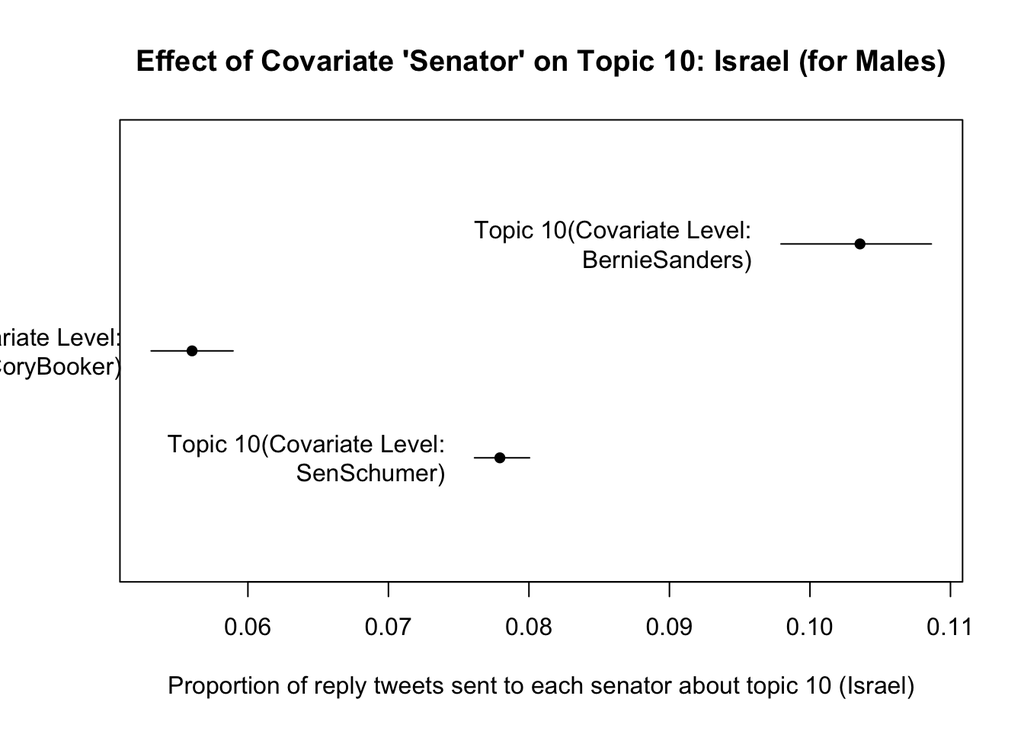

```r
# Estimate Covariate Effects
prep <- estimateEffect(1:15 ~ reply_to_screen_name,model,meta=meta,uncertainty="Global",documents=docs)

# Topics over Senator - MALE
plot.estimateEffect(prep,"reply_to_screen_name",method="pointestimate",topics=10,printlegend=TRUE,main="Effect of Covariate 'Senator' on Topic 10: Israel (for Males)",ci.level=.95,nsims=100, xlab="Proportion of reply tweets sent to each senator about topic 10 (Israel)")
```

```r
# Saving Covariate Effects
pdf('TopicCovariate_M.pdf')
plot.estimateEffect(prep,"reply_to_screen_name",method="pointestimate",topics=10,printlegend=TRUE,main="Effect of Covariate 'Senator' on Topic 10: Israel (for Males)",ci.level=.95,nsims=100, xlab="Proportion of reply tweets sent to each senator about topic 10 (Israel)")
dev.off()
```